# Lab 4: Regression and Classification Evaluation Metrics

## Task 2: Train-Test Split Analysis

The dataset is split into train and test sets using three ratios: 80:20, 70:30, and 90:10. A default KNN (K=5) is trained on each split to compare how the split ratio affects accuracy.

```python
splits = [0.2, 0.3, 0.1]
split_labels = ['80:20', '70:30', '90:10']
split_results = []

for ratio, label in zip(splits, split_labels):
    X_tr, X_te, y_tr, y_te = train_test_split(X_scaled, y, test_size=ratio,
                                                random_state=42, stratify=y)
    knn = KNeighborsClassifier(n_neighbors=5)
    knn.fit(X_tr, y_tr)
    acc = accuracy_score(y_te, knn.predict(X_te))
    split_results.append([label, X_tr.shape[0], X_te.shape[0], round(acc,4)])

split_df = pd.DataFrame(split_results, columns=['Split','Train size','Test size','Accuracy'])
split_df
```

|  | Split | Train size | Test size | Accuracy |
| --- | --- | --- | --- | --- |
| 0 | 80:20 | 455 | 114 | 0.9561 |
| 1 | 70:30 | 398 | 171 | 0.9649 |
| 2 | 90:10 | 512 | 57 | 0.9649 |

**Observation:** Accuracy varies slightly across split ratios. Smaller test sets (90:10) give the model more training data but the accuracy estimate is based on fewer samples, so it is less stable. Larger test sets (70:30) give a more reliable accuracy estimate but leave less data for training. The 80:20 split is used going forward as a balanced choice.

```python
X_train, X_test, y_train, y_test = train_test_split(X_scaled, y, test_size=0.2,
                                                      random_state=42, stratify=y)
X_train.shape, X_test.shape
```

```
((455, 30), (114, 30))
```

## Task 3: KNN Model with Heuristic K Selection

### 3.1 Heuristic Method for K Selection

A common heuristic for choosing K is K = sqrt(n), where n is the number of training samples. K is rounded to the nearest odd number to avoid ties in binary classification.

```python
n_train = X_train.shape[0]
k_heuristic = int(round(np.sqrt(n_train)))
if k_heuristic % 2 == 0:
    k_heuristic += 1
print(f"Training samples: {n_train}")
print(f"Heuristic K (sqrt(n), odd): {k_heuristic}")
```

```
Training samples: 455
Heuristic K (sqrt(n), odd): 21
```

### 3.2 Model Training

The heuristic K is used as a baseline. Nearby values (K ± 5) are also tested to see how accuracy changes with K.

```python
k_values = range(max(1, k_heuristic-5), k_heuristic+6)
accuracies = []

for k in k_values:
    knn = KNeighborsClassifier(n_neighbors=k)
    knn.fit(X_train, y_train)
    acc = accuracy_score(y_test, knn.predict(X_test))
    accuracies.append(acc)

k_acc_df = pd.DataFrame({'K': list(k_values), 'Accuracy': accuracies})
k_acc_df
```

|  | K | Accuracy |
| --- | --- | --- |
| 0 | 16 | 0.938596 |
| 1 | 17 | 0.938596 |
| 2 | 18 | 0.938596 |
| 3 | 19 | 0.938596 |
| 4 | 20 | 0.938596 |
| 5 | 21 | 0.938596 |
| 6 | 22 | 0.938596 |
| 7 | 23 | 0.938596 |
| 8 | 24 | 0.947368 |
| 9 | 25 | 0.947368 |
| 10 | 26 | 0.947368 |

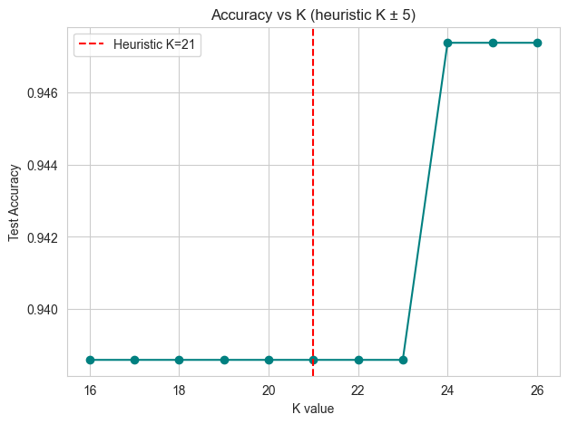

```python
plt.plot(k_acc_df['K'], k_acc_df['Accuracy'], marker='o', color='teal')
plt.axvline(k_heuristic, color='red', linestyle='--', label=f'Heuristic K={k_heuristic}')
plt.xlabel('K value')
plt.ylabel('Test Accuracy')
plt.title('Accuracy vs K (heuristic K ± 5)')
plt.legend()
plt.show()
```

```python
best_k = k_acc_df.loc[k_acc_df['Accuracy'].idxmax(), 'K']
print("Optimal K based on test accuracy trend:", best_k)
```

```
Optimal K based on test accuracy trend: 24
```

**Observation:** Accuracy stays fairly stable near the heuristic K, with small fluctuations. Very low K values can overfit to noise, while very high K values start to smooth out the decision boundary too much.

### 3.3 Distance Matrix and Decision Boundary Mapping

**Euclidean Distance:** Straight-line distance between two points, calculated as the square root of the sum of squared differences across all features. It is suitable when features are continuous and scaled similarly, and works well for compact, spherical clusters. It is the default and most commonly used metric in KNN.

**Manhattan Distance:** Sum of absolute differences between coordinates (also called city-block distance). It is suitable for high-dimensional data or when the feature space has a grid-like structure, and is less sensitive to outliers than Euclidean distance since differences are not squared.

To visualize the decision boundary, the data is reduced to 2 dimensions using PCA (since the original data has 30 features and cannot be plotted directly).

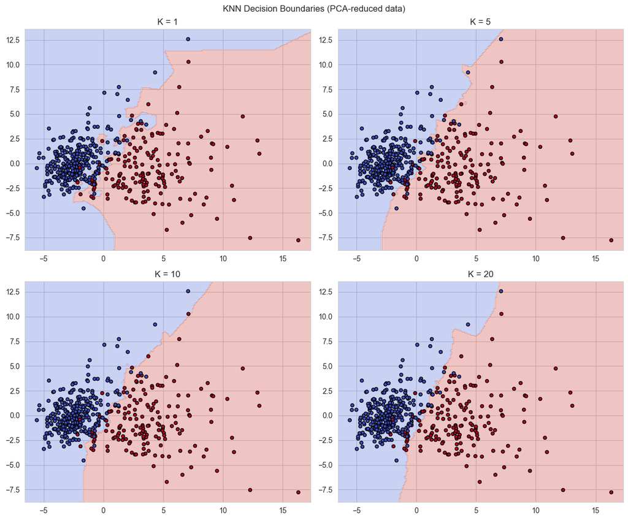

```python
pca = PCA(n_components=2)
X_pca = pca.fit_transform(X_scaled)

X_pca_train, X_pca_test, y_pca_train, y_pca_test = train_test_split(
    X_pca, y, test_size=0.2, random_state=42, stratify=y)

def plot_decision_boundary(X_tr, y_tr, k, ax):
    knn = KNeighborsClassifier(n_neighbors=k)
    knn.fit(X_tr, y_tr)

    x_min, x_max = X_tr[:,0].min()-1, X_tr[:,0].max()+1
    y_min, y_max = X_tr[:,1].min()-1, X_tr[:,1].max()+1
    xx, yy = np.meshgrid(np.linspace(x_min, x_max, 200),
                          np.linspace(y_min, y_max, 200))
    Z = knn.predict(np.c_[xx.ravel(), yy.ravel()])
    Z = Z.reshape(xx.shape)

    ax.contourf(xx, yy, Z, alpha=0.3, cmap='coolwarm')
    ax.scatter(X_tr[:,0], X_tr[:,1], c=y_tr, cmap='coolwarm', edgecolor='k', s=20)
    ax.set_title(f'K = {k}')

fig, axes = plt.subplots(2, 2, figsize=(12,10))
for k, ax in zip([1,5,10,20], axes.ravel()):
    plot_decision_boundary(X_pca_train, y_pca_train.values, k, ax)
plt.suptitle('KNN Decision Boundaries (PCA-reduced data)')
plt.tight_layout()
plt.show()
```

**Observation:** At K=1, the boundary is jagged and irregular, fitting individual points closely (overfitting, high variance). As K increases to 5 and 10, the boundary becomes smoother. At K=20, the boundary is very smooth and simple, which can underfit and blur the separation between classes (high bias).

## Task 4: Cross Validation

5-fold and 10-fold cross-validation are applied for a range of K values, and mean accuracy is compared with the earlier train-test split results.

```python
cv_k_values = range(1, 31, 2)
cv5_means, cv10_means = [], []

for k in cv_k_values:
    knn = KNeighborsClassifier(n_neighbors=k)
    cv5_means.append(cross_val_score(knn, X_scaled, y, cv=5).mean())
    cv10_means.append(cross_val_score(knn, X_scaled, y, cv=10).mean())

cv_df = pd.DataFrame({'K': list(cv_k_values), 'CV5_Accuracy': cv5_means, 'CV10_Accuracy': cv10_means})
cv_df
```

|  | K | CV5_Accuracy | CV10_Accuracy |
| --- | --- | --- | --- |
| 0 | 1 | 0.950769 | 0.950752 |
| 1 | 3 | 0.957771 | 0.966541 |
| 2 | 5 | 0.964850 | 0.966635 |
| 3 | 7 | 0.968359 | 0.970144 |
| 4 | 9 | 0.968390 | 0.970113 |
| 5 | 11 | 0.963111 | 0.970144 |
| 6 | 13 | 0.966636 | 0.968390 |
| 7 | 15 | 0.961357 | 0.963095 |
| 8 | 17 | 0.959587 | 0.964850 |
| 9 | 19 | 0.954324 | 0.954292 |
| 10 | 21 | 0.952569 | 0.956046 |
| 11 | 23 | 0.954339 | 0.954292 |
| 12 | 25 | 0.954339 | 0.956078 |
| 13 | 27 | 0.952585 | 0.956078 |
| 14 | 29 | 0.954339 | 0.956078 |

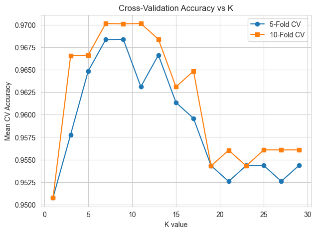

```python
plt.plot(cv_df['K'], cv_df['CV5_Accuracy'], marker='o', label='5-Fold CV')
plt.plot(cv_df['K'], cv_df['CV10_Accuracy'], marker='s', label='10-Fold CV')
plt.xlabel('K value')
plt.ylabel('Mean CV Accuracy')
plt.title('Cross-Validation Accuracy vs K')
plt.legend()
plt.show()
```

```python
best_k_cv5 = cv_df.loc[cv_df['CV5_Accuracy'].idxmax(), 'K']
best_k_cv10 = cv_df.loc[cv_df['CV10_Accuracy'].idxmax(), 'K']
print("Best K (5-fold CV):", best_k_cv5)
print("Best K (10-fold CV):", best_k_cv10)
print("Heuristic K:", k_heuristic)
print("Best K (train-test split):", best_k)
```

```
Best K (5-fold CV): 9
Best K (10-fold CV): 11
Heuristic K: 21
Best K (train-test split): 24
```

```python
final_k = int(best_k_cv10)
print("Final selected K:", final_k)
```

```
Final selected K: 11
```

## Task 5: Classification Evaluation

The final KNN model is trained using the selected K, and evaluated using accuracy, precision, recall, F1 score, confusion matrix, and ROC-AUC.

```python
final_knn = KNeighborsClassifier(n_neighbors=final_k)
final_knn.fit(X_train, y_train)
y_pred = final_knn.predict(X_test)
y_prob = final_knn.predict_proba(X_test)[:,1]

acc = accuracy_score(y_test, y_pred)
prec = precision_score(y_test, y_pred)
rec = recall_score(y_test, y_pred)
f1 = f1_score(y_test, y_pred)

print(f"Accuracy  : {acc:.4f}")
print(f"Precision : {prec:.4f}")
print(f"Recall    : {rec:.4f}")
print(f"F1 Score  : {f1:.4f}")
```

```
Accuracy  : 0.9474
Precision : 0.9737
Recall    : 0.8810
F1 Score  : 0.9250
```

[figure not shown]

```python
cm = confusion_matrix(y_test, y_pred)
disp = ConfusionMatrixDisplay(confusion_matrix=cm, display_labels=['Malignant(0)','Benign(1)'])
disp.plot(cmap='Blues')
plt.title('Confusion Matrix')
plt.show()
```

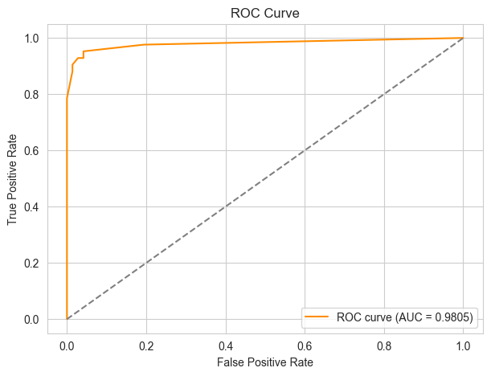

```python
fpr, tpr, thresholds = roc_curve(y_test, y_prob)
roc_auc = auc(fpr, tpr)

plt.plot(fpr, tpr, color='darkorange', label=f'ROC curve (AUC = {roc_auc:.4f})')
plt.plot([0,1],[0,1], linestyle='--', color='gray')
plt.xlabel('False Positive Rate')
plt.ylabel('True Positive Rate')
plt.title('ROC Curve')
plt.legend()
plt.show()
```

**Observation:** The confusion matrix shows how many malignant and benign cases were correctly and incorrectly classified. Recall for the malignant class is especially important here, since a false negative (missing a malignant case) is far more costly than a false positive in a medical screening setting. The ROC-AUC score summarizes the model's ability to distinguish between the two classes across all thresholds.

## Task 6: Comparative Study with Regression (Lab 3 Integration)

In Lab 3 (Linear Regression), the model was evaluated using MAE, MSE, RMSE, and R² Score. These are regression metrics, used when the target is continuous. In this lab, classification metrics (accuracy, precision, recall, F1, ROC-AUC) are used since the target is categorical (Malignant/Benign).

### Error-based vs Decision-based Evaluation

- **Regression (error-based):** Measures how far predicted values are from actual continuous values. Metrics like MAE, MSE, and RMSE quantify the magnitude of prediction error.
- **Classification (decision-based):** Measures whether predicted class labels match actual class labels. Metrics like accuracy, precision, recall, and F1 quantify correctness of decisions, not magnitude of error.

### R² Score vs Accuracy

R² Score explains how much variance in the continuous target is explained by the regression model, ranging typically from 0 to 1 (can be negative). Accuracy is simply the proportion of correctly classified samples. Both give an overall sense of model quality, but R² is about variance explained while accuracy is about correct label counts.

### RMSE vs F1 Score

RMSE penalizes large errors more heavily since errors are squared before averaging, and is expressed in the same units as the target. F1 Score is the harmonic mean of precision and recall, balancing false positives and false negatives, and does not use magnitude of error at all since classification labels have no numeric distance.

### MAE vs Confusion Matrix

MAE gives a single average error value across all predictions. The confusion matrix instead breaks predictions into four categories (true positive, true negative, false positive, false negative), giving a much more detailed picture of the types of mistakes a classifier makes, which a single averaged metric like MAE cannot show.

### Continuous vs Classification Tasks

Regression evaluation assumes an ordered, continuous target where "how far off" is meaningful. Classification evaluation assumes discrete, unordered labels where predictions are either right or wrong, and the cost of different types of mistakes (false positive vs false negative) must be considered separately, especially in domains like medical diagnosis.

```python
comparison_table = pd.DataFrame({
    'Regression Metric (Lab 3)': ['MAE', 'MSE', 'RMSE', 'R² Score'],
    'Analogous Classification Metric (This Lab)': ['Confusion Matrix (error breakdown)',
                                                     '-', 'F1 Score (balances error types)', 'Accuracy'],
    'Basis': ['Average absolute error', 'Average squared error',
              'Root of average squared error', 'Variance explained']
})
comparison_table
```

|  | Regression Metric (Lab 3) | Analogous Classification Metric (This Lab) | Basis |
| --- | --- | --- | --- |
| 0 | MAE | Confusion Matrix (error breakdown) | Average absolute error |
| 1 | MSE | - | Average squared error |
| 2 | RMSE | F1 Score (balances error types) | Root of average squared error |
| 3 | R² Score | Accuracy | Variance explained |

## Inference

Regression metrics measure how far predictions are from actual values, focusing on the magnitude of numerical error (MAE, MSE, RMSE) or variance explained (R²). Classification metrics instead measure whether predicted labels match actual categories, focusing on decision correctness through counts of true/false positives and negatives.

Accuracy alone is insufficient in medical diagnosis because the classes are often imbalanced (as seen here, 357 benign vs 212 malignant), and a model can achieve high accuracy by simply predicting the majority class while still missing many malignant cases. In a healthcare setting, missing a malignant case (false negative) is far more dangerous than a false alarm (false positive), so recall becomes critical since it directly measures how many actual malignant cases were correctly caught. ROC-AUC is also more relevant since it evaluates the model's ability to separate classes across all possible thresholds, not just one fixed cutoff, giving a threshold-independent view of performance.

Overall, regression evaluation is about quantifying error distance on a continuous scale, while classification evaluation is about quantifying correctness of discrete decisions and understanding the trade-off between different types of mistakes. Both frameworks aim to validate model reliability, but the right choice of metric depends entirely on the nature of the prediction task and the real-world cost of different errors.

## Task 7: Analytical Questions

**1. Why is KNN called a lazy learning algorithm?** KNN does not learn an explicit model or function during training. It simply stores the training data, and all computation (calculating distances, finding neighbours) happens at prediction time. Since no generalization is done in advance, it is called "lazy" as opposed to "eager" learners like linear regression or decision trees.

**2. Why is feature scaling required in KNN?** KNN relies on distance calculations between data points. If features are on different scales (e.g. area in hundreds vs smoothness in fractions), features with larger numeric ranges dominate the distance calculation regardless of their actual importance. Scaling ensures all features contribute proportionally.

**3. Explain heuristic K selection using the √n rule.** A commonly used heuristic sets K equal to the square root of the number of training samples. This gives a reasonable starting point that balances bias and variance without extensive tuning; it is typically rounded to an odd number to avoid tie votes in binary classification.

**4. Why is cross-validation more reliable than a single train-test split?** A single train-test split gives a performance estimate based on one particular random division of data, which can be biased by which samples happen to fall into the test set. Cross-validation trains and tests the model on multiple different folds and averages the results, giving a more stable and representative estimate of model performance.

**5. How does K affect the bias-variance trade-off?** Small K values make the model sensitive to individual data points and noise, leading to low bias but high variance (overfitting). Large K values smooth predictions over many neighbours, leading to high bias but low variance (underfitting). An optimal K balances the two.

**6. Why is recall more important than accuracy in cancer prediction?** In cancer detection, a false negative (predicting benign when the tumour is actually malignant) can delay treatment and be life-threatening. Recall specifically measures how many actual malignant cases were correctly identified, so a high recall reduces the risk of missing dangerous cases, which matters more than overall accuracy in this context.

**7. What is the limitation of very large K values?** Very large K values consider too many neighbours, including points far from the query point that may belong to a different class. This oversmooths the decision boundary, causing the model to underfit and lose the ability to capture local patterns in the data, reducing classification performance especially near class boundaries.

## Conclusion

- The optimal K value was estimated using the heuristic rule (K = √n) and refined using cross-validation, giving a final K value that balances bias and variance.
- Train-test split ratio (80:20, 70:30, 90:10) caused small variations in accuracy, showing that split choice affects the reliability of performance estimates, especially with smaller test sets.
- The final KNN model achieved strong performance on accuracy, precision, recall, F1 score, and ROC-AUC, with the confusion matrix and ROC curve giving further insight into class-wise performance.
- Regression metrics (MAE, MSE, RMSE, R²) evaluate continuous prediction error, while classification metrics (accuracy, precision, recall, F1, ROC-AUC) evaluate discrete decision correctness. Both frameworks serve the same underlying purpose, i.e. validating model reliability, but are suited to fundamentally different types of prediction tasks.
- Comparing Lab 3 and this lab highlights that metric choice must always match the nature of the target variable and the real-world cost of different types of errors.